# SECR - tutorial

```r
library(dplyr)
library(secr)
```

# Dati

```r
hareCH6 <- read.capthist("data/hareCH6capt.txt",
                         "data/hareCH6trap.txt",
                         detector = "single")
```

```
No errors found :-)
```

```r
summary(hareCH6)
```

```
Object class       capthist
Detector type      single
Detector number    100
Average spacing    60.96 m
x-range            0 548.64 m
y-range            0 548.64 m

Counts by occasion
```

|  | 1 | 2 | 3 | 4 | 5 | 6 | Total |
| --- | --- | --- | --- | --- | --- | --- | --- |
| n | 16 | 28 | 20 | 26 | 23 | 32 | 145 |
| u | 16 | 24 | 9 | 9 | 6 | 4 | 68 |
| f | 25 | 22 | 13 | 5 | 1 | 2 | 68 |
| M(t+1) | 16 | 40 | 49 | 58 | 64 | 68 | 68 |
| losses | 0 | 0 | 0 | 0 | 0 | 0 | 0 |
| detections | 16 | 28 | 20 | 26 | 23 | 32 | 145 |
| detectors visited | 16 | 28 | 20 | 26 | 23 | 32 | 145 |
| detectors used | 100 | 100 | 100 | 100 | 100 | 100 | 600 |

n = numero di individui diversi rilevati in ciascuna occasione *t* (6 occasioni)  
u = numero di individui rilevati per la prima volta in ciascuna occasione *t*  
f = numero di individui rilevati esattamente in *t* occasioni  
M(t+1) = numero cumulativo di individui rilevati in ciascuna occasione *t*

Plot dei dati spaziali, con spezzata che unisce la catture consecutive di uno stesso individuo:

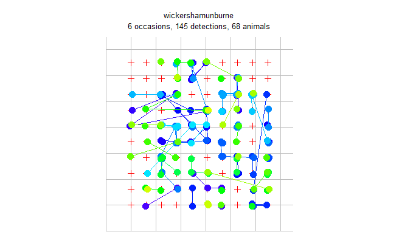

```r
par(mar = c(1,1,3,1)) # riduce i margini, param grafico
plot(hareCH6, tracks = TRUE)
```

Scala spaziale (sigma) - prima stima:

```r
initialsigma <- RPSV(hareCH6, CC = TRUE)
cat("Quick and biased estimate of sigma =", initialsigma, "m\n")
```

```
Quick and biased estimate of sigma = 63.66117 m
```

La scala spaziale ci serve per definire un buffer attorno alle nostre trappole - il buffer serve a definire l’area che viene usata per stimare la densità, e deve essere abbastanza ampio affinche gli animali che sono al bordo dell’area abbiano una probabilità pari a 0 di finire nel nostro campione. Di norma, 4 per sigma è una distanza sufficiente (perché stiamo adottando una distribuzione *half-normal*, e questa soglia è definita su base empirica)

```r
fit
```

```
secr.fit(capthist = hareCH6, buffer = 4 * initialsigma, trace = FALSE)
secr 4.6.6, 17:43:58 04 mar 2024

Detector type      multi
Detector number    100
Average spacing    60.96 m
x-range            0 548.64 m
y-range            0 548.64 m

N animals       :  68
N detections    :  145
N occasions     :  6
Mask area       :  106.1286 ha

Model           :  D~1 g0~1 sigma~1
Fixed (real)    :  none
Detection fn    :  halfnormal
Distribution    :  poisson
N parameters    :  3
Log likelihood  :  -607.9883
AIC             :  1221.977
AICc            :  1222.352

Beta parameters (coefficients)
```

|  | beta | SE.beta | lcl | ucl |
| --- | --- | --- | --- | --- |
| D | 0.382512 | 0.12995435 | 0.1278062 | 0.6372179 |
| g0 | -2.723728 | 0.16091310 | -3.0391115 | -2.4083437 |
| sigma | 4.224543 | 0.06530753 | 4.0965429 | 4.3525438 |

```
Variance-covariance matrix of beta parameters
                 D           g0        sigma
D      0.016888133 -0.001729426 -0.001624204
g0    -0.001729426  0.025893027 -0.007372120
sigma -0.001624204 -0.007372120  0.004265073

Fitted (real) parameters evaluated at base levels of covariates
```

|  | link | estimate | SE.estimate | lcl | ucl |
| --- | --- | --- | --- | --- | --- |
| D | log | 1.46596252 | 0.191315375 | 1.1363328 | 1.89121198 |
| g0 | logit | 0.06158768 | 0.009299914 | 0.0456899 | 0.08253866 |
| sigma | log | 68.34328707 | 4.468094598 | 60.1320476 | 77.67579970 |

```
NA
```

L’ultima tabella è quella che ci interessa di più. La stima di densità è di 1.47 lepri per ettaro, con un intervallo di confidenza di 1.14-1.89.  
Gli altri due parametri (g0 e sigma) sono invece riferiti alla curva che descrive la diminuzione della *detection probability* all’aumentare della distanza dal centro di attività dell’animale:

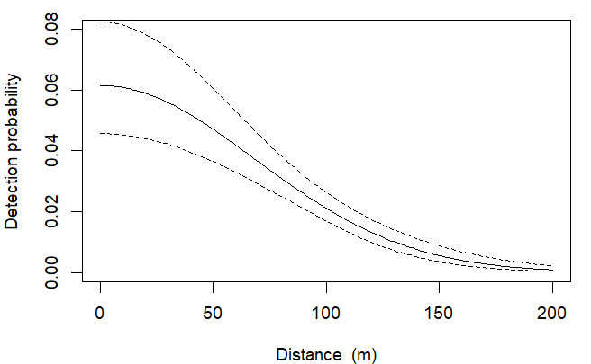

```r
par(mar = c(4,4,1,1)) # reduce margins
plot(fit, limits = TRUE)
```

# Verifica sul valore del buffer

Come detto sopra, il valore di sigma iniziale serve a definire il buffer per la stima della densità. Verifichiamo che esso vada bene con il seguente plot:

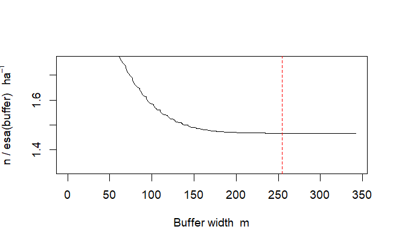

```r
esa.plot(fit)
abline(v = 4 * initialsigma, lty = 2, col = 'red')
```

che ci dice che alla distanza scelta per il buffer (indicata dalla linea tratteggiata rossa), la stima della densità ha già raggiunto un asintoto (cioè non cambia più al variare della distanza)

# Approfondimento sulla detection function

Nel modello che abbiamo appena fittato, abbiamo assunto che la probabilità di avvistare un animale diminuisca con la distanza secondo un modello *half-normal*, ma possono essere applicati altri modelli, i più comuni sono *negative exponential* e *hazard rate*

```r
fit.HN <- secr.fit (hareCH6, buffer = 6 * initialsigma, detectfn = 'HN', trace = FALSE)
fit.EX <- secr.fit (hareCH6, buffer = 6 * initialsigma, detectfn = 'EX', trace = FALSE)
fit.HR <- secr.fit (hareCH6, buffer = 6 * initialsigma, detectfn = 'HR', trace = FALSE)
```

```r
fits <- secrlist(HN = fit.HN, EX = fit.EX, HR = fit.HR)
predict(fits)
```

|  | link | estimate | SE.estimate | lcl | ucl |
| --- | --- | --- | --- | --- | --- |
| D | log | 1.46590446 | 0.191329023 | 1.13625590 | 1.89119007 |
| g0 | logit | 0.06160565 | 0.009296521 | 0.04571222 | 0.08254698 |
| sigma | log | 68.33102529 | 4.461153495 | 60.13181362 | 77.64823205 |

|  | link | estimate | SE.estimate | lcl | ucl |
| --- | --- | --- | --- | --- | --- |
| D | log | 1.4771496 | 0.1949285 | 1.1417794 | 1.9110269 |
| g0 | logit | 0.1797172 | 0.0309932 | 0.1267146 | 0.2485793 |
| sigma | log | 39.9178908 | 3.2925632 | 33.9685158 | 46.9092619 |

|  | link | estimate | SE.estimate | lcl | ucl |
| --- | --- | --- | --- | --- | --- |
| D | log | 1.3549075 | 0.19366057 | 1.0253207 | 1.7904391 |
| g0 | logit | 0.1291053 | 0.03646133 | 0.0727986 | 0.2186908 |
| sigma | log | 45.3664848 | 8.43519286 | 31.6089660 | 65.1118403 |
| z | log | 3.1151584 | 0.31342280 | 2.5589068 | 3.7923273 |

```
NA
```

NB. confrontate soltanto i valori di D, perché sigma ha significato diverso a seconda dei modelli

|  | model | detectfn | npar | logLik | AIC | AICc | dAICc | AICcwt |
| --- | --- | --- | --- | --- | --- | --- | --- | --- |
| HR | D~1 g0~1 sigma~1 z~1 | hazard rate | 4 | -599.8802 | 1207.760 | 1208.395 | 0.000 | 0.6467 |
| EX | D~1 g0~1 sigma~1 | exponential | 3 | -601.6145 | 1209.229 | 1209.604 | 1.209 | 0.3533 |
| HN | D~1 g0~1 sigma~1 | halfnormal | 3 | -607.9913 | 1221.983 | 1222.358 | 13.963 | 0.0000 |

Dal confronto degli AIC vediamo che il modello selezionato sarebbe quello con la funzione *hazard rate*. Tuttavia, con questo modello la stima della densità resta sensibile all’area del buffer (non si raggiunge un asintoto):

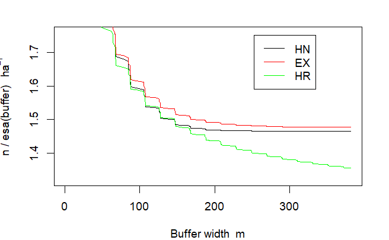

```r
par(mar = c(4,4,2,2))
esa.plot(fits, max.buffer = 6 * initialsigma)
```

Per questo motivo, è di solito sconsigliato l’uso della funzione *hazard rate* nel SECR, a meno che non vi sia una buona ragione ecologica per farlo (es. presenza di barriere che fanno sì che la probabilità di cattura crolli con la distanza in maniera più netta dopo un primo *plateau*).

Il modello migliore, escludendo l’*hazard rate*, è quindi quello esponenziale negativo (la stima non cambia significativamente rispetto all’*half normal*).

In alternativa, possiamo anche fare un *model averaging* dei modelli:

```r
modelAverage(secrlist(HN = fit.HN, EX = fit.EX), criterion = "AICc")
```

[output not shown]

# Parametri del modello SECR

Nel modello di base, ogni parametro stimato è costante (D ~ 1, g0 ~ 1, sigma ~ 1), non dipende da altri parametri. Ma possiamo inserire dei predittori, o variabili esplicative, per ciascn parametro del modello SECR.

|  | model | detectfn | npar | logLik | AIC | AICc | dAICc | AICcwt |
| --- | --- | --- | --- | --- | --- | --- | --- | --- |
| b | D~1 g0~b sigma~1 | exponential | 4 | -599.8239 | 1207.648 | 1208.283 | 0.000 | 0.5004 |
| null | D~1 g0~1 sigma~1 | exponential | 3 | -601.6145 | 1209.229 | 1209.604 | 1.321 | 0.2585 |
| bk | D~1 g0~bk sigma~1 | exponential | 4 | -600.5544 | 1209.109 | 1209.744 | 1.461 | 0.2410 |

```r
fit.EXb
```

```
secr.fit(capthist = hareCH6, model = g0 ~ b, buffer = 6 * initialsigma,
    detectfn = "EX", trace = FALSE)
secr 4.6.6, 18:39:35 04 mar 2024

Detector type      multi
Detector number    100
Average spacing    60.96 m
x-range            0 548.64 m
y-range            0 548.64 m

N animals       :  68
N detections    :  145
N occasions     :  6
Mask area       :  160.3395 ha

Model           :  D~1 g0~b sigma~1
Fixed (real)    :  none
Detection fn    :  exponential
Distribution    :  poisson
N parameters    :  4
Log likelihood  :  -599.8239
AIC             :  1207.648
AICc            :  1208.283

Beta parameters (coefficients)
```

|  | beta | SE.beta | lcl | ucl |
| --- | --- | --- | --- | --- |
| D | 0.5660897 | 0.19302750 | 0.18776275 | 0.9444166 |
| g0 | -2.0175425 | 0.38003412 | -2.76239570 | -1.2726893 |
| g0.bTRUE | 0.6084635 | 0.36067987 | -0.09845606 | 1.3153831 |
| sigma | 3.6928425 | 0.08260366 | 3.53094230 | 3.8547427 |

```
Variance-covariance matrix of beta parameters
                    D          g0     g0.bTRUE        sigma
D         0.037259615 -0.04689393  0.048765863 -0.001900332
g0       -0.046893926  0.14442593 -0.112727193 -0.013732576
g0.bTRUE  0.048765863 -0.11272719  0.130089970  0.000164086
sigma    -0.001900332 -0.01373258  0.000164086  0.006823364

Fitted (real) parameters evaluated at base levels of covariates
```

|  | link | estimate | SE.estimate | lcl | ucl |
| --- | --- | --- | --- | --- | --- |
| D | log | 1.7613661 | 0.34318380 | 1.20654723 | 2.5713129 |
| g0 | logit | 0.1173733 | 0.03937033 | 0.05939039 | 0.2187972 |
| sigma | log | 40.1588360 | 3.32293346 | 34.15613781 | 47.2164658 |

```
NA
```

Possiamo anche considerare altri predittori:

- b: permanent global learned response
- bk: permanent detector-specific learned response
- t: time factor (one level for each occasion)
- T: time trend (integer covariate 0:(S-1))
- g: group (as specified by ‘groups’ argument)
- session: session factor (one level for each session)

Altri esempi:  
https://www.otago.ac.nz/density/examples/index.html